# Gender Pay Gap analysis

```r
library("readxl")
data_1 <- read_xlsx(file.choose())
```

dim(data_1)

str(data_1)

```r
table(data_1$Job_type)
```

```
##
## High_Paid  Low_Paid
##        89       111
```

```r
(table(data_1$Job_type)=="Low_Paid")/((table(data_1$Job_type)=="LowPaid")+ (table(data_1$Job_type)=="High_Paid"))
```

```
##
## High_Paid  Low_Paid
##       NaN       NaN
```

```r
summary (data_1)
```

```
##    Job_type            Gender            workAmount        salary
##  Length:200         Length:200         Min.   :22.97   Min.   : 68.02
##  Class :character   Class :character   1st Qu.:31.29   1st Qu.: 79.33
##  Mode  :character   Mode  :character   Median :36.58   Median : 86.83
##                                        Mean   :36.35   Mean   : 94.87
##                                        3rd Qu.:40.84   3rd Qu.:111.94
##                                        Max.   :53.16   Max.   :128.09
```

checking the number of missing values per column

```r
colSums(is.na(data_1))
```

```
##   Job_type     Gender workAmount     salary
##          0          0          0          0
```

```r
# no missing values present
```

Bivariate Analysis through visualizations:

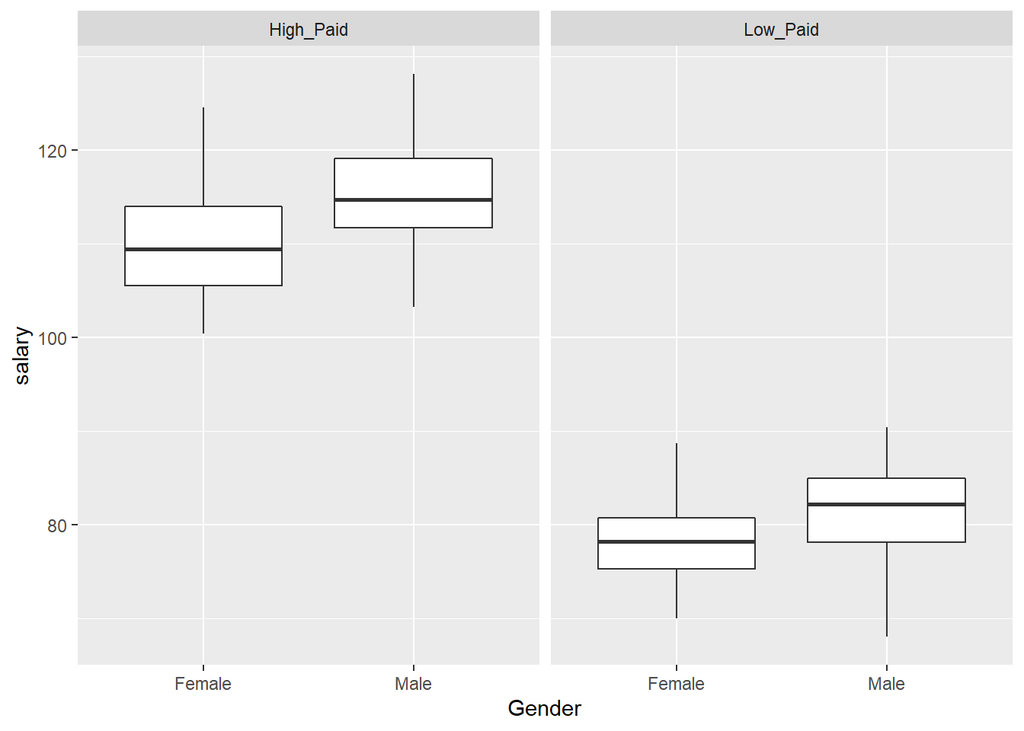

```r
# salary and Gender

library(ggplot2)

viz1 <- ggplot(data = data_1, aes(y=salary, x= Gender)) + geom_boxplot() + facet_wrap(~Job_type)

viz1
```

more analysis can be done by seeing the actual mean, median, and mode but from the visualizations, it can also be seen that taking the median salary (in the subcategories of high paid and low paid), male have a higher salary as compared to females.

```r
# Linear regression with job type and gender

lmmodel_1 <- lm (salary ~ Job_type+Gender, data = data_1)
summary(lmmodel_1)
```

```
##
## Call:
## lm(formula = salary ~ Job_type + Gender, data = data_1)
##
## Residuals:
##      Min       1Q   Median       3Q      Max
## -13.9320  -3.9684  -0.1269   3.1720  13.4723
##
## Coefficients:
##                  Estimate Std. Error t value Pr(>|t|)
## (Intercept)      111.0677     0.7218 153.873  < 2e-16 ***
## Job_typeLow_Paid -33.2616     0.7642 -43.527  < 2e-16 ***
## GenderMale         4.1459     0.7626   5.436  1.6e-07 ***
## ---
## Signif. codes:  0 '***' 0.001 '**' 0.01 '*' 0.05 '.' 0.1 ' ' 1
##
## Residual standard error: 5.357 on 197 degrees of freedom
## Multiple R-squared:  0.909,  Adjusted R-squared:  0.9081
## F-statistic: 983.7 on 2 and 197 DF,  p-value: < 2.2e-16
```

all variables all highly significant and we can interpret it as MAles earn $4.15 more than Females. Whoa, clear indication of gender gap .

Visualtions that shows correlations with the variables:

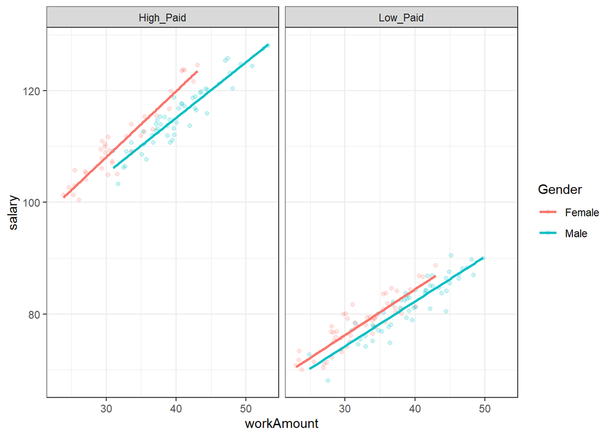

```r
library(ggplot2)

viz2 <- ggplot(data = data_1, aes(y = salary, x = workAmount, color = Gender, group = Gender)) +
    theme_bw() +
    geom_point(alpha = 0.2) +
    geom_smooth(method = "lm", se = FALSE) +
    facet_wrap(~Job_type)  # facet_wrap used when using multiple visualizations
viz2
```

From the visualization, it can be seen that per amlount of work done, females are paid more, hence again gap in the payment. This also shows a positive correlation, but should not be confused with causation.

```r
# creating linear model taking into consideration the work amount also

lmmodel_2 <- lm (salary ~ Job_type+Gender+workAmount, data = data_1)
summary(lmmodel_2)
```

```
##
## Call:
## lm(formula = salary ~ Job_type + Gender + workAmount, data = data_1)
##
## Residuals:
##     Min      1Q  Median      3Q     Max
## -6.1194 -1.6144  0.1392  1.4536  4.7603
##
## Coefficients:
##                   Estimate Std. Error  t value Pr(>|t|)
## (Intercept)       80.62589    1.01573   79.377  < 2e-16 ***
## Job_typeLow_Paid -32.72912    0.31307 -104.541  < 2e-16 ***
## GenderMale        -2.90554    0.38472   -7.552 1.59e-12 ***
## workAmount         0.93499    0.02985   31.323  < 2e-16 ***
## ---
## Signif. codes:  0 '***' 0.001 '**' 0.01 '*' 0.05 '.' 0.1 ' ' 1
##
## Residual standard error: 2.192 on 196 degrees of freedom
## Multiple R-squared:  0.9848, Adjusted R-squared:  0.9846
## F-statistic:  4246 on 3 and 196 DF,  p-value: < 2.2e-16
```

Th Coefficients value also state the same that males earn less ($2.91K per year) per work amount as compared to females. Also, in the statistics, since the regression lines are not parallel, so this also shows there is a gap in the salary and its not same.

Imp -> Since there seems to be some interaction between gender and work amount (as seen from the previous graph), so we can use interaction term in our regression model to see the relation.

```r
lmmodel_3 <- lm (salary ~ Job_type+Gender*workAmount, data = data_1)
summary(lmmodel_3)
```

```
##
## Call:
## lm(formula = salary ~ Job_type + Gender * workAmount, data = data_1)
##
## Residuals:
##    Min     1Q Median     3Q    Max
## -5.920 -1.584  0.076  1.518  4.796
##
## Coefficients:
##                        Estimate Std. Error  t value Pr(>|t|)
## (Intercept)            78.89157    1.49846   52.648   <2e-16 ***
## Job_typeLow_Paid      -32.75438    0.31233 -104.872   <2e-16 ***
## GenderMale              0.43969    2.16582    0.203    0.839
## workAmount              0.98928    0.04562   21.685   <2e-16 ***
## GenderMale:workAmount  -0.09443    0.06017   -1.569    0.118
## ---
## Signif. codes:  0 '***' 0.001 '**' 0.01 '*' 0.05 '.' 0.1 ' ' 1
##
## Residual standard error: 2.183 on 195 degrees of freedom
## Multiple R-squared:  0.985,  Adjusted R-squared:  0.9847
## F-statistic:  3209 on 4 and 195 DF,  p-value: < 2.2e-16
```

Now usiing Random Forest to estimate the predictive performance or in other words, we need to see if we can predict salary from all the other predictors.

```r
library(caret)
rf_model <- train(salary~Job_type + Gender + workAmount, data = data_1,
                    method = "rf", tuneLength = 2, ntree = 2000,
                    trControl = trainControl(method = "cv", number = 10, verboseIter = FALSE))

rf_model
```

```
## Random Forest
##
## 200 samples
##   3 predictor
##
## No pre-processing
## Resampling: Cross-Validated (10 fold)
## Summary of sample sizes: 180, 180, 180, 180, 180, 180, ...
## Resampling results across tuning parameters:
##
##   mtry  RMSE      Rsquared   MAE
##   2     2.345153  0.9843863  1.920594
##   3     2.359514  0.9834302  1.932184
##
## RMSE was used to select the optimal model using the smallest value.
## The final value used for the model was mtry = 2.
```

```r
library(randomForest)
m1 <- randomForest(salary~. , data=data_1)

getTree(m1,1)
```

```
##   left daughter right daughter split var split point status prediction
## 1             2              3         1       1.500     -3   92.78935
## 2             4              5         3      36.945     -3  113.18051
## 3             6              7         2       1.500     -3   79.47612
## 4             8              9         2       1.500     -3  107.36000
## 5             0              0         0       0.000     -1  117.57822
## 6             0              0         0       0.000     -1   77.77581
## 7             0              0         0       0.000     -1   82.15319
## 8             0              0         0       0.000     -1  106.00368
## 9             0              0         0       0.000     -1  109.07800
```

```r
# but this should not be used because we have not split the data into training and test set. So first we should split it into traing and test set and then prepare the model.
```

Splitting the data into training and test (although we have just 200 records and overfitting chances are less even if we do not split into training an dtest model)

```r
library(fastDummies)
results_dummy_1 <- dummy_cols(data_1, remove_most_frequent_dummy = T) # the one which has the highest frequency will not be shown among all its levels

names(results_dummy_1) # just to ensure taht all the names are correct
```

```
## [1] "Job_type"           "Gender"             "workAmount"
## [4] "salary"             "Job_type_High_Paid" "Gender_Female"
```

```r
results_dummy_1 [,c("Gender","Job_type")] <- list(NULL)

names(results_dummy_1)
```

```
## [1] "workAmount"         "salary"             "Job_type_High_Paid"
## [4] "Gender_Female"
```

```r
# since from these we created the dummy variables and hence we dont need these actual variables now
```

```r
library(caret)
# splitting the data into train test split
results_dummy_1 <- results_dummy_1[sample(nrow(results_dummy_1)),] # shuffle the data as per rows

#dummy index

trainIndex_1 <- createDataPartition(results_dummy_1$salary, p=0.7, list = FALSE)

x_train_1<- results_dummy_1[trainIndex_1,] # get all the columns but onlky those rows that match the ones in trainIndex
x_test_1 <- results_dummy_1[-trainIndex_1,]

dim(x_train_1) # As seen, 140 records are set to training data and remaining 60 are set to testing data
```

```
## [1] 140   4
```

```r
dim(x_test_1)
```

```
## [1] 60  4
```

Creating Random Forest on training data

```r
library(randomForest)
r_model_1 <- randomForest(salary~., data=x_train_1)

r_model_1 # since its a regression model only where we need to predict the salary (i.e. the continuous variable, so type of random Forest : Regression )
```

```
##
## Call:
##  randomForest(formula = salary ~ ., data = x_train_1)
##                Type of random forest: regression
##                      Number of trees: 500
## No. of variables tried at each split: 1
##
##           Mean of squared residuals: 35.84828
##                     % Var explained: 88.97
```

Feature Importance of various variables using iml package

```r
library(iml)

importance(r_model_1)
```

```
##                    IncNodePurity
## workAmount              6096.792
## Job_type_High_Paid     26509.438
## Gender_Female            873.953
```

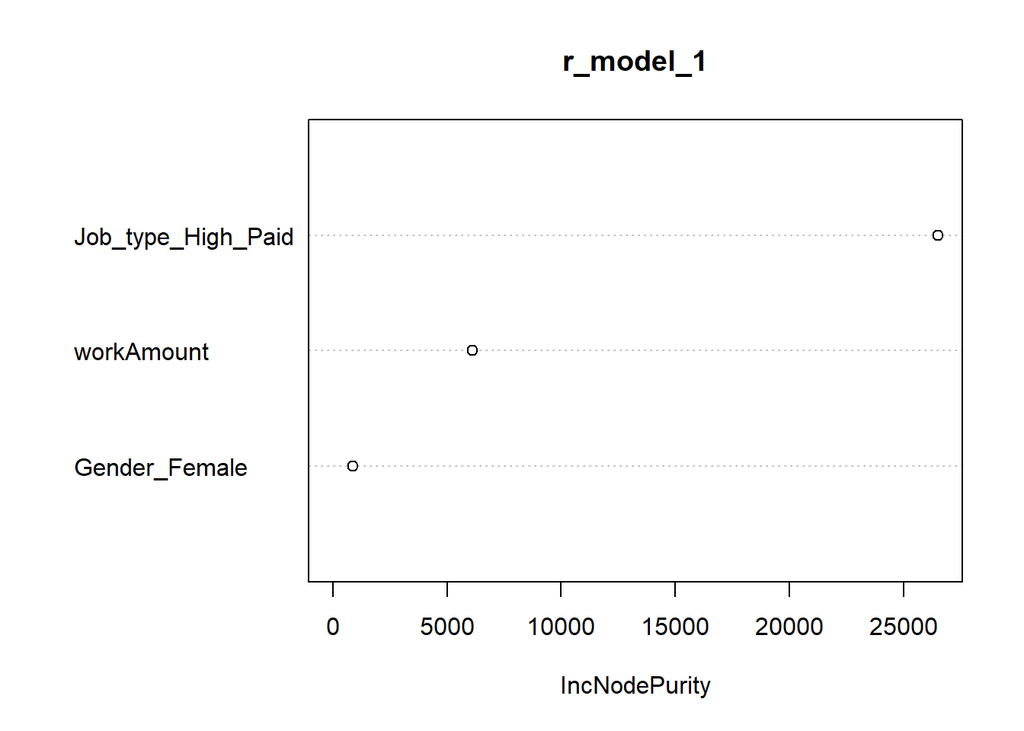

```r
varImpPlot(r_model_1, type = 2)
```

From feature importance, it can be seen that gender does not make much of a difference in predicting the salary outcome. So the HR team should prepare such an organization structure where the salary is distributed as per the amount of work that is done. Moreover, the discrimination in the gap analysis can also be analysed taking into consideration data from various departments (which is also one of the best practices to do modeling in people analytics) and various other columns like age, number of promotions, percentage hike, amount of hours spent etc. This model was created taking into account the dummy data and did not intend to discriminate or negate teh gender gap but encourage to use such predictive models to introduce a predictive framework.